# Quiz 1: Part 2

## Part 2: Coding in action

### Instructions

Please answer these questions in R using whatever syntax makes sense to you. Feel free to use the R help pages and/or notes from class.

**If you use Google or ChatGPT etc. to help you get to an answer, please note so on your answer**

Submit your answers as an html file. Name it “lastname_quiz1.html”. Two submission options:  
1. Create a branch in your forked-and-cloned class repo. Add the html file to the student_contributions/ folder. Submit a pull request to Sabrina (preferred); 2. Email it to mcnew@arizona.edu (if github is really giving you a headache)

```r
# load packages and data
library(ggplot2)
library(dslabs)
library(dplyr)
```

#### Load your data:

You also have a separate data frame called *brightness.csv* where each row lists the plumage brightness (a sexual signal) for the female at each nest. Load this one up too.

```r
# Answer
swallows <- read.csv("swallows.csv")
brightness <- read.csv("brightness.csv")

# Google? N
```

#### Wrangle your data

```r
#Answer

swallows <- swallows |> rename(nest_id=nestbox)

brightness <- brightness |> rename(nest_id=nestbox)

swallows_full <- full_join(swallows,brightness)
# I inspected the dataframe and saw that the columns had combined, and that the nest_id name for the column remained through the join.

#Google? N
```

Inspect your combined data frame. Do some sort of quick sanity check on each column to catch any obvious entry errors. Correct as necessary

```r
# Answer
str(swallows_full)
```

```
'data.frame':   42 obs. of  5 variables:
 $ nest_id   : chr  "2_124" "2_22" "2_109" "2_8" ...
 $ treatment : chr  "Control" "Control" "Predation" "Control" ...
 $ brood     : int  6 5 5 5 6 3 4 5 5 5 ...
 $ n_fledged : int  2 5 2 3 6 2 4 5 1 4 ...
 $ brightness: num  58.4 57.7 NA 55.7 58.6 54.2 41.5 39.9 49.3 68 ...
```

```r
#comparisons between old and new data frames
table(swallows_full$treatment)
```

```
  Control Predation
       20        22
```

```r
table(swallows$treatment)
```

```
  Control Predation
       20        22
```

```r
max(swallows_full$brood)
```

```
[1] 7
```

```r
max(swallows$brood)
```

```
[1] 7
```

```r
min(swallows_full$n_fledged)
```

```
[1] 0
```

```r
min(swallows$n_fledged)
```

```
[1] 0
```

```r
# Google y/n N
```

Create a new column called prop_fledged that contains the proportion of nestlings that fledged from each nest.

```r
#Answer

swallows_full <- swallows_full |> mutate(prop_fledged = n_fledged/brood)

# Google? y/n N
```

#### Explore the data

What was the mean proportion of nestlings fledged in each treatment?

```r
# Answer
swallows_full |> summarize(mean(prop_fledged, na.rm=TRUE), .by = treatment)
```

```
  treatment mean(prop_fledged, na.rm = TRUE)
1   Control                        0.7055556
2 Predation                        0.3349206
```

```r
# Google? y/n N
```

Create a plot showing fledging success differences between treatments

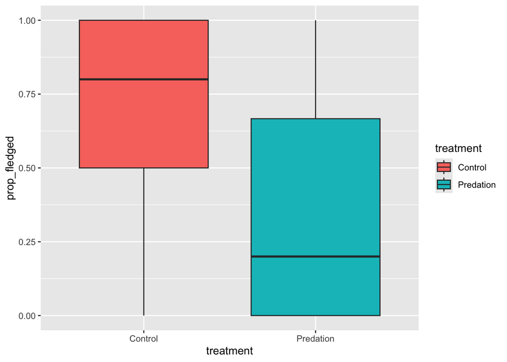

```r
# Answer

fledge_success <- swallows_full |> ggplot(aes(x=treatment, y=prop_fledged, fill=treatment)) + geom_boxplot()

fledge_success
```

```r
# Google? y/n
```

Is there any evidence that female brightness influenced fledging success? Create a plot to visually investigate this question.

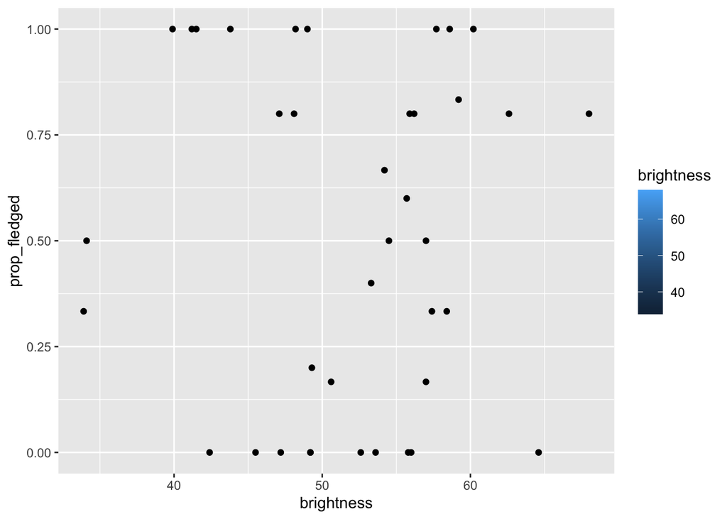

```r
# Answer

fledge_success_bright <- swallows_full |> ggplot(aes(x=brightness, y=prop_fledged, fill=brightness)) + geom_point()

fledge_success_bright
```

```r
cor.test(swallows_full$brightness,swallows_full$prop_fledged)
```

```
    Pearson's product-moment correlation

data:  swallows_full$brightness and swallows_full$prop_fledged
t = -0.026032, df = 36, p-value = 0.9794
alternative hypothesis: true correlation is not equal to 0
95 percent confidence interval:
 -0.3235731  0.3157828
sample estimates:
        cor
-0.00433858
```

```r
#No evidence of relationship

# Google? y/n N
```